# Writing your own tailor-made user-built functions in R

## 4.6. Fool-prooving your function with respect to argument inputs

What happens if you provide, for example, a non-numeric value for the numeric argument “**size**” in your function?

```r
# spiral_fun(size = "t")

# Error in (1 - log_boolean) * size :
#   non-numeric argument to binary operator
```

**If there is an inappropriate input into your function, your code might stop running altogether.**

Sometimes, this might be what you want, because the stopping might alert you to some fundamental errors in your code.

**However, sometimes, you might wish to run your code, even if there is the occasional inappropriate input into your function.**

Therefore, you might wish to include into your **function body code** some code that returns error messages if the **argument input** is inappropriate.

1. Provide default values for your function **arguments**  
2. Write a routine in your **function body code** that deals with **argument input** errors

```r
spiral_fun <- function(size = 1, shape = 1, log_boolean = FALSE, log_shape = 0.1)
{

# Description: this function draws a spiral
# Archimedean spiral: log_boolean = FALSE, shape = 1
# Logarythmic spiral: log_boolean = TRUE (e.g., log_shape = 0.1)
# Hyperbolic spiral: shape = -1
# Fermat spiral: shape = 0.5
# Lituus spiral: shape = -0.5

if (!is.numeric(size) | !is.numeric(shape) | !is.numeric(log_shape)
    | !is.logical(log_boolean) | !(min(log_boolean %in% c(0,1))) |
    length(size) + length(shape) + length(log_boolean) + length(log_shape) > 4)
{
  print("Warning: Provided argument(s) of wrong class or length, function reverts to default values")
  size = 1
  shape = 1
  log_boolean = FALSE
  log_shape = 0.1

}

  phy = c(2 *pi * c(1:360) / 45)
  r = (1-log_boolean) * size * phy ^ shape + log_boolean * size * exp(phy * log_shape)
  x = r * cos(phy)
  y = r * sin(phy)
  plot(x, y, type = 'l')

}
```

What happens now if you provide a non-numeric value for **size**?

```r
spiral_fun(size = "t")
```

```
## [1] "Warning: Provided argument(s) of wrong class or length, function reverts to default values"
```

```r
spiral_fun(size = c(1, 2, 10))
```

```
## [1] "Warning: Provided argument(s) of wrong class or length, function reverts to default values"
```

[figure not shown]

Alternatively, you might wish to only give a warning and not execute the function at all.

```r
spiral_fun <- function(size = 1, shape = 1, log_boolean = FALSE, log_shape = 0.1)
{

# Description: this function draws a spiral
# Archimedean spiral: log_boolean = FALSE, shape = 1
# Logarythmic spiral: log_boolean = TRUE (e.g., log_shape = 0.1)
# Hyperbolic spiral: shape = -1
# Fermat spiral: shape = 0.5
# Lituus spiral: shape = -0.5

if (!is.numeric(size) | !is.numeric(shape) | !is.numeric(log_shape)
    | !is.logical(log_boolean) | !(min(log_boolean) %in% c(0,1)) |
    length(size) + length(shape) + length(log_boolean) + length(log_shape) > 4)
{
  print("Warning: Provided argument(s) of wrong class or length, function will not be executed")
}
else {
  phy = c(2 *pi * c(1:360) / 45)
  r = (1-log_boolean) * size * phy ^ shape + log_boolean * size * exp(phy * log_shape)
  x = r * cos(phy)
  y = r * sin(phy)
  plot(x, y, type = 'l')
}

}
```

What happens now if you provide a non-numeric value for **size**?

```r
spiral_fun(size = "t")
```

```
## [1] "Warning: Provided argument(s) of wrong class or length, function will not be executed"
```

```r
spiral_fun(log_boolean = c(TRUE, FALSE))
```

```
## [1] "Warning: Provided argument(s) of wrong class or length, function will not be executed"
```

There are many further ways to fool-proof your function argument input.

You could consider including code in your function that limits the **range** of your argument inputs.

For example, for the simple one-argument function **arg1_fun** at the beginning, you might want to limit the **input range** of the argument **int1** to integer values **between 1 and 3**.

Or you might to wish to give more detailed warnings. For example **which argument** is the problem, or whether argument **class or length** is the problem.

.. and so on ..

You can include all kinds of fool-proofing for your **argument inputs** within your **function body code**

## 4.7. Local and global arguments in R

The arguments which we have talked about so far, were all **local arguments**.

That is, the arguments were all either given as **input arguments** to the function (e.g., “**size**”, “**shape**”,…); or they were defined **within** the function body code (e.g., “**x**”, “**y**”,…).

However, your function can also use **global arguments**. **Global arguments** are sitting in the main (“**global**”) body of your code **outside** of functions or function inputs.

Let’s have a look at the following function.

```r
spiral_fun_no_size <- function(shape = 1, log_boolean = FALSE, log_shape = 0.1)
{

# Description: this function draws a spiral

  phy = c(2 *pi * c(1:360) / 45)
  r = (1-log_boolean) * size * phy ^ shape + log_boolean * size * exp(phy * log_shape)
  x = r * cos(phy)
  y = r * sin(phy)
  plot(x, y, type = 'l')

}
```

If I now call the function **spiral_fun_no_size**, R cannot find a value for the argument **size** **locally**, either in the function arguments **spiral_fun_no_size(shape, log_boolean , log_shape)** nor within the **function body code**.

```r
# spiral_fun_no_size()

# Error in spiral_fun_no_size() : object 'size' not found
```

However, I can set a value for **argument size** (e.g., size = 10) **globally** within the main body of my code and outside of my function **spiral_fun_no_size**.

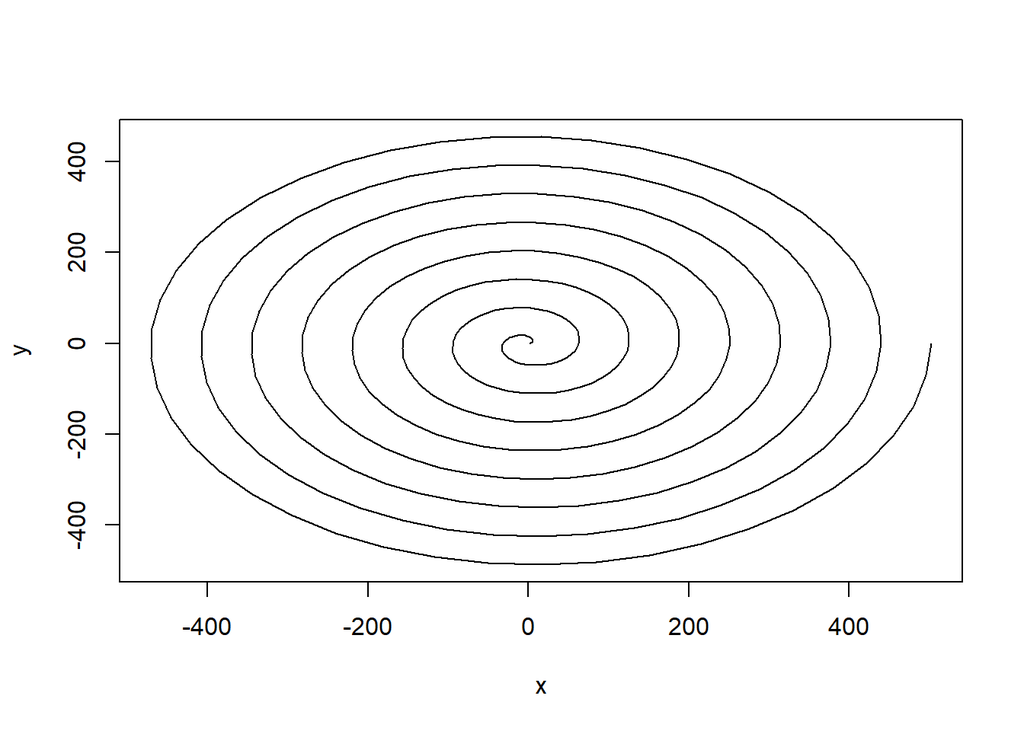

```r
size = 10

spiral_fun_no_size()
```

Generally, if you call a function, R **first** searches for a **local value** for all the arguments required by the function.

If R cannot find a **local value**, R **then** looks for a **global value** (e.g., a value provided in the main body of the code before the function is called).

## 5. Function outputs: return

The following function **text_fun** has as first argument a text string **text1**.

It counts and cleans **text1** of non-letter characters; and formats it into lines of length **l_width**.

It also counts number of words and characters and creates a **wordcloud**.

Its potential outputs are:

Number of error characters **no_errors**

Number of characters **no_chars**

Number of words **no_words**

Cleaned text **text_clean**

Formatted text for printing **text_formatted**

Wordcloud **word_cloud**

```r
# install.packages("stringi")
# install.packages("wordcloud")
# install.packages("tm")


text_fun <- function(text1, l_width){

# Description: the function (i) cleans the text of non-letter characters and superfluous spaces;
# (ii) counts the original errors in the text, the number of characters and the number of words;
# (iii) formats the text into lines for a finer print out;
# and (iv) provides a word cloud


## (i) text cleaning

# list of special characters to be removed from the text
special_chars = c("@", "#", "$", "%", "=", "+", "£", "*", "(", ")", "/", "\\", as.character(c(0:9)))

# removing special characters from the text
text_clean <- gsub("  ", " ", stringi::stri_replace_all_fixed(str = text1, pattern = special_chars,
                              replacement = rep("", length(special_chars)), vectorize_all=FALSE))

## (ii) text statistics

# calculating the number of errors, words and final characters in the text
no_errors <- nchar(text1) - nchar(text_clean)
no_chars <- nchar(text_clean)
no_words <- lengths(gregexpr("\\W+", text_clean)) + 1   # counts the instances of non-alphanumeric seperations
                                                       # between 'batches' of (1+) alphanumerics

## (iii) text formatting

# break line every 30 characters
text_formatted <- strwrap(text_clean, l_width)
#writeLines(text_formatted)



## (iv) wordcloud

text_cloud <- gsub("[[:punct:]]", "", tolower(text_clean))
v_temp <- sort(rowSums(as.matrix(tm::TermDocumentMatrix(tm::tm_map(tm::Corpus(tm::VectorSource(text_cloud)),
                                         tm::removeWords, tm::stopwords("english"))))),decreasing=TRUE)
## function in function

word_cloud <- function(v = v_temp){
set.seed(12135)
wordcloud::wordcloud(words = data.frame(word = names(v),freq=v)$word, freq = data.frame(word = names(v),
          freq=v)$freq, min.freq = 1, random.order=FALSE, rot.per=0.35,
         # colors = brewer.pal("Set2"))
         colors = c("#87CEFA", "#DA70D6","#B22222", "#698B22", "#FFD700")
         )
}

}
```

Let’s have a look what the function does.

```r
tyger_text
```

```
## [1] "Tyg3er Tyger, burn33ing br/ight, I(n the fo$rests *of the ni%ght; What immortal hand or eye, Could fr++ame thy fearful s8ymmetry? In w£ha=t dis9tant  dee$ps or skies. Burnt th++e fir/e of thine eyes? On wha7t  win1gs d$are he aspire? What the ha@nd, da/re seize the fire? And0  what shoulder,…
```

```r
text_fun(text1 = tyger_text, l_width = 30)
```

**??**

By default, the R functions will **return** the last evaluated object inside it.

But nothing more, unless you **explicitly** tell your R function to do so.

You can tell R explicitely what to return by using **return()** within your R function.

Let’s modify our function **text_fun** by including **return** instructions.

```r
# install.packages("stringi")
# install.packages("wordcloud")
# install.packages("tm")


text_fun <- function(text1, l_width){

# Description: the function (i) cleans the text of non-letter characters and superfluous spaces;
# (ii) counts the original errors in the text, the number of characters and the number of words;
# (iii) formats the text into lines for a finer print out;
# and (iv) provides a word cloud


## (i) text cleaning

# list of special characters to be removed from the text
special_chars = c("@", "#", "$", "%", "=", "+", "£", "*", "(", ")", "/", "\\", as.character(c(0:9)))

# removing special characters from the text
text_clean <- gsub("  ", " ", stringi::stri_replace_all_fixed(str = text1, pattern = special_chars,
                              replacement = rep("", length(special_chars)), vectorize_all=FALSE))

## (ii) text statistics

# calculating the number of errors, words and final characters in the text
no_errors <- nchar(text1) - nchar(text_clean)
no_chars <- nchar(text_clean)
no_words <- lengths(gregexpr("\\W+", text_clean)) + 1   # counts the instances of non-alphanumeric seperations
                                                       # between 'batches' of (1+) alphanumerics

## (iii) text formatting

# break line every 30 characters
text_formatted <- strwrap(text_clean, l_width)
#writeLines(text_formatted)



## (iv) wordcloud

text_cloud <- gsub("[[:punct:]]", "", tolower(text_clean))
v_temp <- sort(rowSums(as.matrix(tm::TermDocumentMatrix(tm::tm_map(tm::Corpus(tm::VectorSource(text_cloud)),
                                         tm::removeWords, tm::stopwords("english"))))),decreasing=TRUE)

## function in function
word_cloud <- function(v = v_temp){
set.seed(12135)
wordcloud::wordcloud(words = data.frame(word = names(v),freq=v)$word, freq = data.frame(word = names(v),
          freq=v)$freq, min.freq = 1, random.order=FALSE, rot.per=0.35,
         # colors = brewer.pal("Set2"))
         colors = c("#87CEFA", "#DA70D6","#B22222", "#698B22", "#FFD700")
         )
}


return(c(Errors = no_errors, Characters = no_chars, Words = no_words))


}
```

Let’s have a look what the function does now.

```r
text_fun(text1 = tyger_text, l_width = 30)
```

```
##     Errors Characters      Words
##         85        775        143
```

The **return()** is especially useful when you want to

- **return more than one output object**
- execute further code within your function after the creation of your output object
- **make your output object conditional**

It is good practice to use **return()** in R functions for greater clarity and to decrease the risk of errors.

Using **return**, R functions can **return** all types of R objects.

However, you can **return** only return **one** object at a time.

If you want to **return** several objects of different classes, you can put them in a object of class **“list”**.

Let’s modify our function **text_fun** by including **return** instructions to return all of the outputs we might be interested in.

```r
# install.packages("stringi")
# install.packages("wordcloud")
# install.packages("tm")


text_fun <- function(text1, l_width){

# Description: the function (i) cleans the text of non-letter characters and superfluous spaces;
# (ii) counts the original errors in the text, the number of characters and the number of words;
# (iii) formats the text into lines for a finer print out;
# and (iv) provides a word cloud


## (i) text cleaning

# list of special characters to be removed from the text
special_chars = c("@", "#", "$", "%", "=", "+", "£", "*", "(", ")", "/", "\\", as.character(c(0:9)))

# removing special characters from the text
text_clean <- gsub("  ", " ", stringi::stri_replace_all_fixed(str = text1, pattern = special_chars,
                              replacement = rep("", length(special_chars)), vectorize_all=FALSE))

## (ii) text statistics

# calculating the number of errors, words and final characters in the text
no_errors <- nchar(text1) - nchar(text_clean)
no_chars <- nchar(text_clean)
no_words <- lengths(gregexpr("\\W+", text_clean)) + 1   # counts the instances of non-alphanumeric seperations
                                                       # between 'batches' of (1+) alphanumerics

## (iii) text formatting

# break line every 30 characters
text_formatted <- strwrap(text_clean, l_width)
#writeLines(text_formatted)



## (iv) wordcloud

text_cloud <- gsub("[[:punct:]]", "", tolower(text_clean))
v_temp <- sort(rowSums(as.matrix(tm::TermDocumentMatrix(tm::tm_map(tm::Corpus(tm::VectorSource(text_cloud)),
                                         tm::removeWords, tm::stopwords("english"))))),decreasing=TRUE)
## function in function
word_cloud <- function(v = v_temp){
set.seed(12135)
wordcloud::wordcloud(words = data.frame(word = names(v),freq=v)$word, freq = data.frame(word = names(v),
          freq=v)$freq, min.freq = 1, random.order=FALSE, rot.per=0.35,
         # colors = brewer.pal("Set2"))
         colors = c("#87CEFA", "#DA70D6","#B22222", "#698B22", "#FFD700")
         )
}


## return output

return(list(Original_text = text1, Errors = no_errors, Text_new = text_clean, Characters = no_chars,
            Words = no_words, Text_nice = text_formatted,
            Cloud = word_cloud))


}
```

Let’s have a look what the function does now.

```r
text_fun(text1 = tyger_text, l_width = 30)
```

```
## $Original_text
## [1] "Tyg3er Tyger, burn33ing br/ight, I(n the fo$rests *of the ni%ght; What immortal hand or eye, Could fr++ame thy fearful s8ymmetry? In w£ha=t dis9tant  dee$ps or skies. Burnt th++e fir/e of thine eyes? On wha7t  win1gs d$are he aspire? What the ha@nd, da/re seize the fire? And0  what shoulder,…
##
## $Errors
## [1] 85
##
## $Text_new
## [1] "Tyger Tyger, burning bright, In the forests of the night; What immortal hand or eye, Could frame thy fearful symmetry? In what distant deeps or skies. Burnt the fire of thine eyes? On what wings dare he aspire? What the hand, dare seize the fire? And what shoulder, & what art, Could twist th…
##
## $Characters
## [1] 775
##
## $Words
## [1] 143
##
## $Text_nice
##  [1] "Tyger Tyger, burning bright,"  "In the forests of the night;"
##  [3] "What immortal hand or eye,"    "Could frame thy fearful"
##  [5] "symmetry? In what distant"     "deeps or skies. Burnt the"
##  [7] "fire of thine eyes? On what"   "wings dare he aspire? What"
##  [9] "the hand, dare seize the"      "fire? And what shoulder, &"
## [11] "what art, Could twist the"     "sinews of thy heart? And when"
## [13] "thy heart began to beat. What" "dread hand? & what dread"
## [15] "feet? What the hammer? what"   "the chain, In what furnace"
## [17] "was thy brain? What the"       "anvil? what dread grasp. Dare"
## [19] "its deadly terrors clasp?"     "When the stars threw down"
## [21] "their spears And water'd"      "heaven with their tears: Did"
## [23] "he smile his work to see? Did" "he who made the Lamb make"
## [25] "thee? Tyger Tyger burning"     "bright, In the forests of the"
## [27] "night: What immortal hand or"  "eye, Dare frame thy fearful"
## [29] "symmetry?"
##
## $Cloud
## function(v = v_temp){
## set.seed(12135)
## wordcloud::wordcloud(words = data.frame(word = names(v),freq=v)$word, freq = data.frame(word = names(v),
##           freq=v)$freq, min.freq = 1, random.order=FALSE, rot.per=0.35,
##          # colors = brewer.pal("Set2"))
##          colors = c("#87CEFA", "#DA70D6","#B22222", "#698B22", "#FFD700")
##          )
## }
## <bytecode: 0x0000023be8d05618>
## <environment: 0x0000023be8275af0>
```

We can assign the function output to a new R object.

```r
tyger_new <- text_fun(text1 = tyger_text, l_width = 30)

class(tyger_new)
```

```
## [1] "list"
```

```r
summary(tyger_new)
```

```
##               Length Class  Mode
## Original_text  1     -none- character
## Errors         1     -none- numeric
## Text_new       1     -none- character
## Characters     1     -none- numeric
## Words          1     -none- numeric
## Text_nice     29     -none- character
## Cloud          1     -none- function
```

```r
# tyger_text

writeLines(tyger_new$Text_nice)
```

```
## Tyger Tyger, burning bright,
## In the forests of the night;
## What immortal hand or eye,
## Could frame thy fearful
## symmetry? In what distant
## deeps or skies. Burnt the
## fire of thine eyes? On what
## wings dare he aspire? What
## the hand, dare seize the
## fire? And what shoulder, &
## what art, Could twist the
## sinews of thy heart? And when
## thy heart began to beat. What
## dread hand? & what dread
## feet? What the hammer? what
## the chain, In what furnace
## was thy brain? What the
## anvil? what dread grasp. Dare
## its deadly terrors clasp?
## When the stars threw down
## their spears And water'd
## heaven with their tears: Did
## he smile his work to see? Did
## he who made the Lamb make
## thee? Tyger Tyger burning
## bright, In the forests of the
## night: What immortal hand or
## eye, Dare frame thy fearful
## symmetry?
```

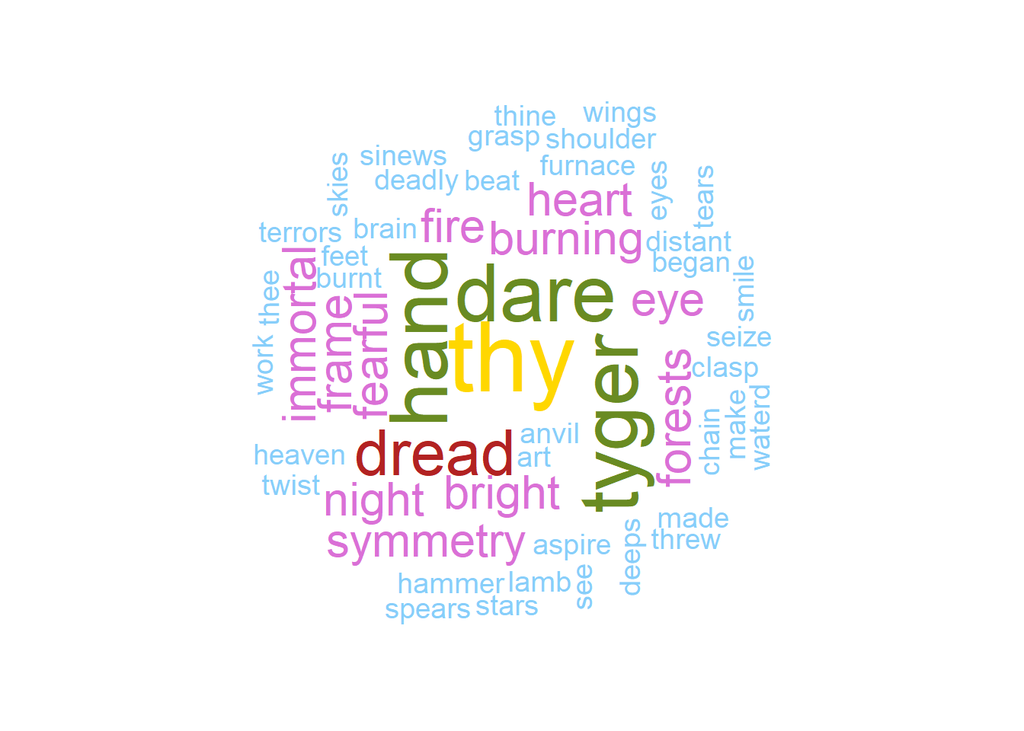

```r
# replayPlot(tyger_new$Cloud)

tyger_new$Cloud()
```

## 6. Check which user defined functions are available within your working environment

It might from time to time be useful to have a look at a list of all the user defined functions available within your working environment. The command **lsf.str()** will list them for you.

```r
# list all available user defined functions in your working environment:

lsf.str()
```

```
## arg1_fun : function (int1)
## simple_fun : function ()
## spiral_fun : function (size = 1, shape = 1, log_boolean = FALSE, log_shape = 0.1)
## spiral_fun_extra : function (size = 1, shape = 0.5, log_boolean = FALSE, log_shape = 0.2,
##     ...)
## spiral_fun_no_size : function (shape = 1, log_boolean = FALSE, log_shape = 0.1)
## text_fun : function (text1, l_width)
```

## 7. Create your own functions library

Once you have written your tailor-made function, you can save and store it in an R file.

It is wise to give the file that contains your function a meaningful name like **function_name.R**.

When you write a new R script, you can easily include your function into your new syntax.

If the source file is saved in the same working directory in which the new script is written and run, you can simply include the function with the command **source(function_name.R)**

```r
# Note:
# I have saved a function "my_demo_fun" in a file called "my_demo_fun.R". However, the Rmarkdown presentation
# cannot access the directory where I have saved the file. When trying to run source("my_demo_fun.R") from the
# presententation Rmarkdown file, it will return an error message:
# Error in my_demo_fun() : could not find function "my_demo_fun"
# However, if you copy the file "my_demo_fun.R" into your own working directory and run the command
# source("my_demo_fun.R") from that working directory, it will work



# If the source file "my_demo_fun.R" is saved in the same working directory in which the new script is written and run, one can simply include the function "my_demo_fun" with the following command:

source("my_demo_fun.R")
```

```r
set.seed(232)

my_demo_fun()
```

```
##
##  Ottilie :  scissors
##  Mordechai :  rock
##
##  Mordechai has won.
##
```

```r
my_demo_fun
```

```
## function (playA = "Ottilie", playB = "Mordechai")
## {
##     res0 <- sample(c(1:3), 2, replace = TRUE)
##     res <- c("rock", "paper", "scissors")[res0]
##     res2 = res0[1] - res0[2]
##     cat("\n", playA, ": ", res[1], "\n", playB, ": ", res[2],
##         "\n")
##     if (res2 == 0) {
##         cat("\n", "Neither", playA, "or", playB, "has won.")
##     }
##     else {
##         if (res2 %in% c(-1, 2)) {
##             cat("\n", playB, "has won.", "\n", "\n")
##         }
##         else {
##             cat("\n", playA, "has won.", "\n", "\n")
##         }
##     }
## }
```

If the function source file **“my_demo_fun.R”** is saved in a different working directory from that in which the new script is written and run, you can include the function **“my_demo_fun”** by including the respective working directory in your command.

```r
# Note:
# The following will not run in the presentation Rmarkdown file, because the presentation Rmarkdown
# code cannot access my working library



# If the source file "my_demo_fun.R" is saved in a different working directory from that in which the new script is written and run, you can include the function "my_demo_fun" by including the respective working directory in your command:


source("C:/Users/conra-l/Documents/DALL/R_Function_Library/spiral_fun_1.R")
```

[figure not shown]

```r
spiral_fun_1()
```

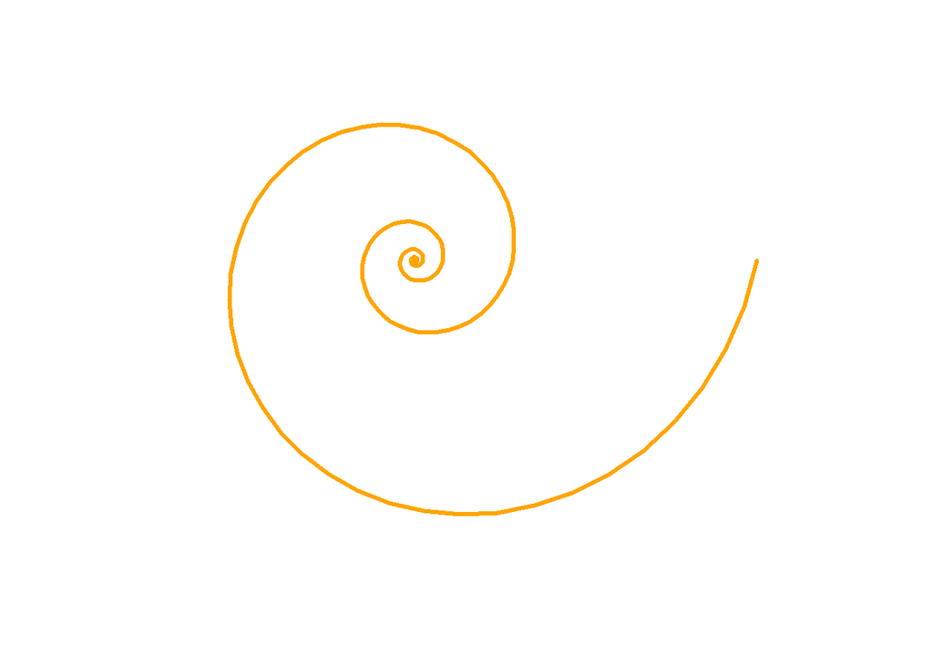

```r
spiral_fun_1(col1 = "orange", type = 'l', log_boolean = TRUE)
```

```r
spiral_fun_1
```

```
## function (size = 1, shape = -0.5, log_boolean = FALSE, log_shape = 0.2,
##     col1 = "purple", type1 = "p", lwd1 = 3, asp1 = 1, ...)
## {
##     phy = c(2 * pi * c(1:360)/45)
##     r = (1 - log_boolean) * size * phy^shape + log_boolean *
##         size * exp(phy * log_shape)
##     x = r * cos(phy)
##     y = r * sin(phy)
##     plot(x, y, axes = FALSE, xlab = "", ylab = "", col = col1,
##         type = type1, lwd = lwd1, asp = asp1, ...)
## }
## <bytecode: 0x0000023be83d5da0>
```

You can also have more than one function in an R syntax file within your function library. The source file “NHS_demo_funs.R” contains four functions. If you source it, all four functions become available in your code.

```r
# Note:
# The following will not run in the presentation Rmarkdown file, because the presentation Rmarkdown
# code cannot access my working library


# The source file "NHS_demo_funs.R" contains four functions. If I source it, all four functions become available in my code.

source("C:/Users/conra-l/Documents/DALL/R_Function_Library/NHS_demo_funs.R")
## list all available functions in NHS_demo_funs.R
#     note that for lsf.str() you have to specify an environment, not a file path

test.env <- new.env()
sys.source("C:/Users/conra-l/Documents/DALL/R_Function_Library/NHS_demo_funs.R", envir = test.env)
lsf.str(envir=test.env)
```

```
## Core20_chart : function (core20_table, my_title)
## key_stats_box : function (values, description)
## LSOA_mapping : function (my_lsoa, my_search = "LSOA name")
## NHS_number_format : function (x)
```

```r
rm(test.env)
```

We can now run these four functions.

Data visualisation.

In reports, we often use tables and charts with similar formats in different sections.  
Writing functions that automatically format our visual presentations might save a lot of time.

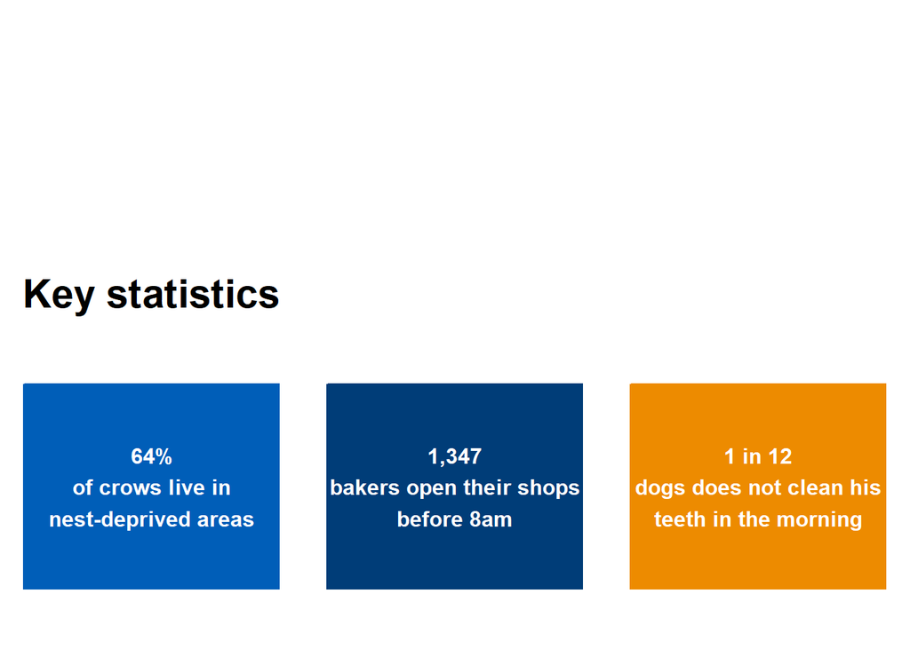

```r
# NHS_Palette


##      Data visualisation:

#       Frequently used table and chart formats


key_stats_box(values = c("64%", "1,347", "1 in 12"),
              description = c("of crows live in nest-deprived areas",
                                  "bakers open their shops before 8am",
                                  "dogs does not clean his teeth in the morning"))
```

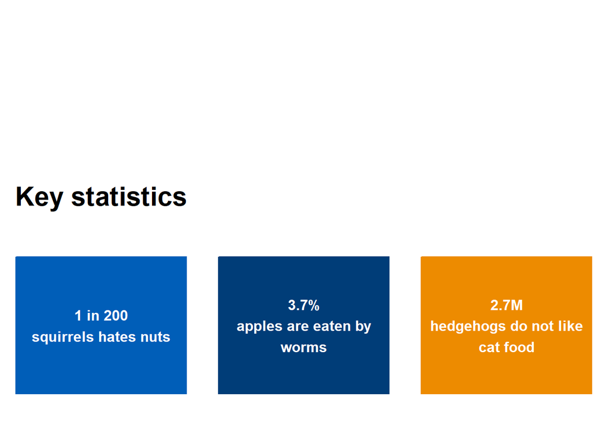

```r
key_stats_box(values = c("1 in 200", "3.7%", "2.7M"),
              description = c("squirrels hates nuts",
                                  "apples are eaten by worms",
                                  "hedgehogs do not like cat food"))
```

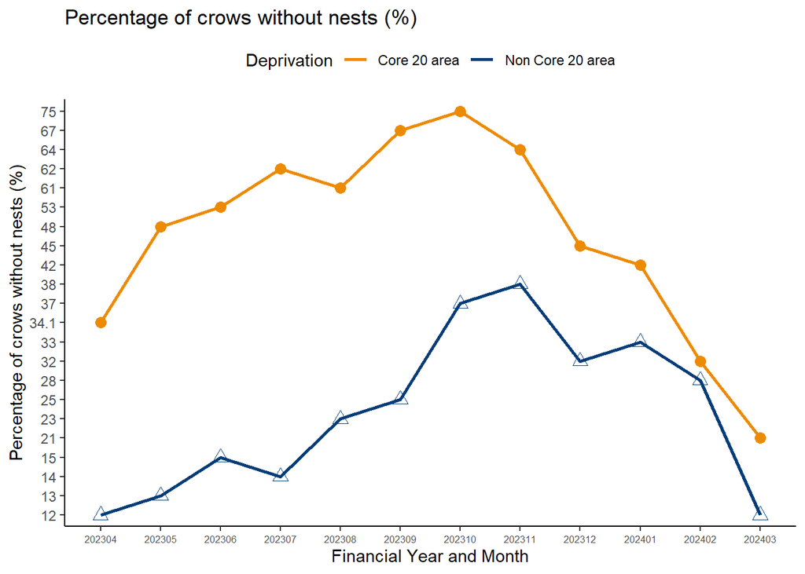

```r
Core20_chart(my_core20_table, my_crows_title)
```

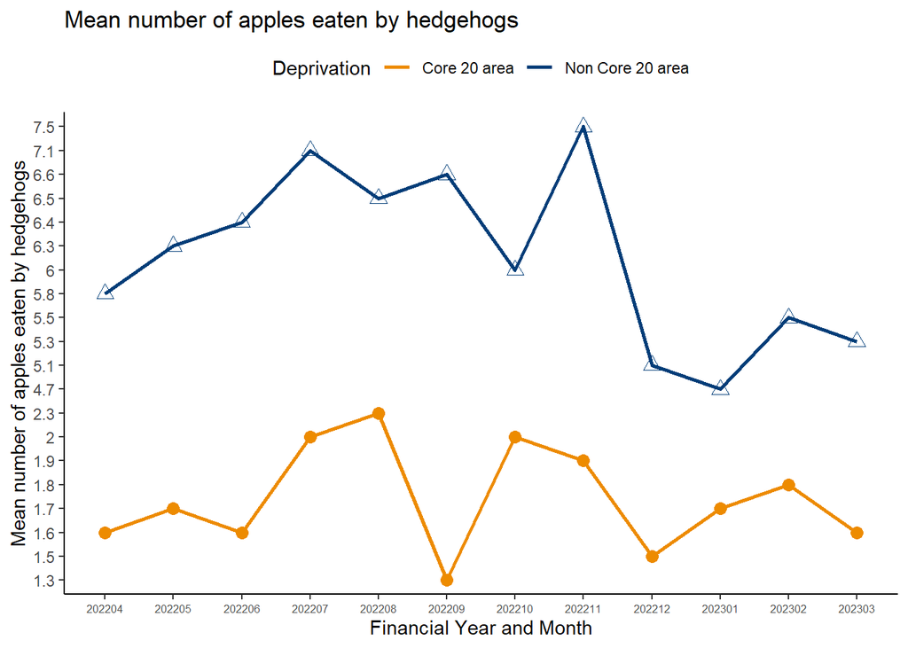

```r
Core20_chart(my_core20_table_2, my_hedgehog_title)
```

Data cleaning and mapping

The following function checks whether a given NHS number is in the correct format.

```r
##      Data cleaning and mapping:

#       Formats (EHIC/GHIC, NHS numbers, NI numbers)

NHS_number_format("123 456 7890")
```

```
## [1] "This is a valid NHS Number format"
```

```r
NHS_number_format("123AAB4567")
```

```
## [1] "This is not a valid NHS Number format"
```

```r
NHS_number_format("12345")
```

```
## [1] "This is not a valid NHS Number format"
```

The following functions offers the option to map the LSOA code to the code, name or imd rank of Wards, SICBLs, ICBs, LADs or NHS regions in Engand.

```r
##      Data cleaning and mapping:

#       Mapping, Geography

LSOA_mapping("E01013481")
```

```
## [1] "For you LSOA code  E01013481  the LSOA name is:    Derby 018A"
```

```r
LSOA_mapping("E01013481", my_search = "Ward name")
```

```
## [1] "For you LSOA code  E01013481  the Ward name is:    Arboretum"
```

```r
LSOA_mapping("E01013481", my_search = "NHS region IMD rank")
```

```
## [1] "For you LSOA code  E01013481  the NHS region IMD rank is:    3"
```

```r
LSOA_mapping("XYZ1013481", my_search = "Ward name")
```

```
## [1] "We cannot find Ward name for LSOA code XYZ1013481. The entered LSOA code might not be valid."
```

```r
LSOA_mapping("E01013481", my_search = "Name of my cat")
```

```
## [1] "Your request cannot be answered with this tool"
```

## 8. Useful websites

https://r-coder.com/function-r/?utm_content=cmp-true

https://rstudio.github.io/r-manuals/r-intro/Writing-your-own-functions.html

https://www.datamentor.io/r-programming/function

https://www.geeksforgeeks.org/functions-in-r-programming/?ref=lbp

https://www.datamentor.io/r-programming/function

https://r4ds.had.co.nz/functions.html

http://adv-r.had.co.nz/Functions.html

https://adv-r.hadley.nz/functions.html

https://www.datacamp.com/tutorial/functions-in-r-a-tutorial

https://www.dataquest.io/blog/r-functions-tutorial/

# Preview of potential further C & C

## 9. Example: Recursive Function in R (still in preparation)

A recursive function is a function or routine that repeatedly calls itself.

```r
fact_rec <- function(n){

  # factorial of integer n

  if (n == 0)
    return(1)
  else
    return(n * fact_rec(n-1))
}
```

The function calculates the fatorial of an integer n  
Namely: n * (n-1) * (n-2) * …. * 1

```r
fact_rec(3)
```

```
## [1] 6
```

```r
fact_rec(6)
```

```
## [1] 720
```

```r
fact_rec(14)
```

```
## [1] 87178291200
```

Recursive functions are a very powerful tool.  
You can with relatively little code generate relatively complex calculations.  
The following function calculates fractal triangles.  
Note that most of the code is required to initiate the R graphics and draw the triangle, not to compute the actual triangles.

```r
FracTriangle_rec <- function(x = 0, y = 0, len = 0.2, farbT = blues9[7])
{
  # Description: This function is a recursive function that calculates and draws a fractal equally-sided triangle

  if (len > 0.002)
    {
    draw_triangle(x, y, len,
          farb = farbT)
    len = len * 0.5
    FracTriangle_rec(x, y + len * sqrt(3)/2, len, farbT)
    FracTriangle_rec(x - len, y - len * sqrt(3)/2, len, farbT)
    FracTriangle_rec(x + len, y - len * sqrt(3)/2, len, farbT)
  }
}


## Graphic helper functions

# Plot initiation function

initiate_triangle <- function(x = 0, y = 0, len = 0.2, my_title = "Fractal triangle", stretch = 1)
  {

  # Description: this function initiates a plot for drawing a equally-sided triangle around origin (x,y) with side length len

  l_corner = c(x - 0.8 * len, y - 0.8 * len) * stretch
  r_corner = c(x + len, y + sqrt(3)/2 * len) * stretch

  plot(c(l_corner[1], r_corner[1]),c(l_corner[2], r_corner[2]), xlab = "", ylab = "", col = "white",
                  main = my_title, asp = 1, col.main = 1,
                  xaxt = "n", yaxt = "n", axes = FALSE)
  }

# Traingle drawing function

 draw_triangle <- function(x = 0, y = 0, len = 0.2, farb = blues9[7])
     {

   # adds to a plot an equally-sided triangle with middle point(x,y) and side legnth len

     lines(c(x - 0.5 * len, x), c(y - 0.5 * len, y + sqrt(3)/4 * len), col = farb)
     lines(c(x - 0.5 * len, x + 0.5 * len), c(y - 0.5 * len, y - 0.5 * len), col = farb)
     lines(c(x + 0.5 * len, x), c(y - 0.5 * len, y + sqrt(3)/4 * len), col = farb)
     }
```

This is the result.

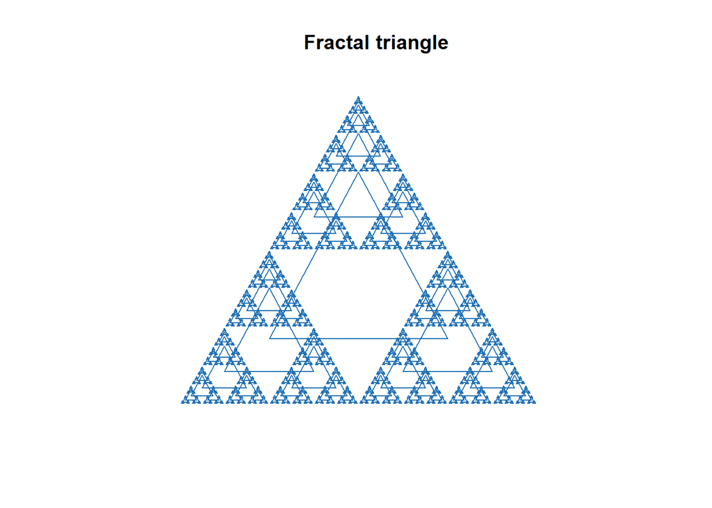

```r
Laenge = 0.2

initiate_triangle(len = Laenge)
FracTriangle_rec(len = Laenge)
```

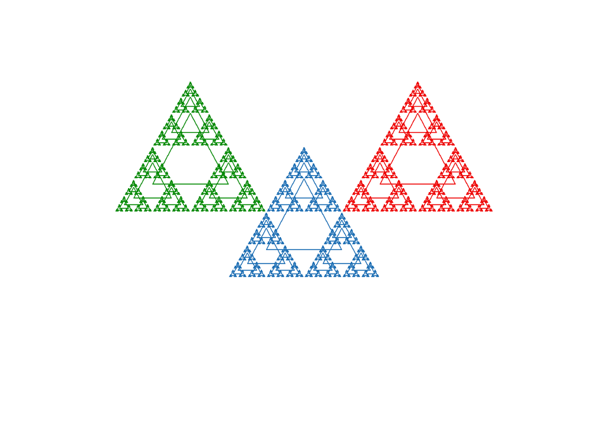

```r
Laenge = 0.1

initiate_triangle(x = , y = , len = Laenge, my_title = "", stretch = 2)
FracTriangle_rec(len = Laenge)
FracTriangle_rec(x = 1.5 * Laenge, y = sqrt(3)/2 * Laenge, len = Laenge, farbT = "red2")
FracTriangle_rec(x = -1.5 * Laenge, y = sqrt(3)/2 * Laenge, len = Laenge, farbT = "green4")
```

Here is another demonstration of the power of recursive functions, calculating and drawing fractal trees.

```r
# Fractal tree

tree_rec <- function(origin = complex(real = 0, imaginary = 0),
                     branch = complex(real = 0, imaginary = 0.5),
                     angle = pi/6 , scale = 0.8, rec_factor = 3)
  {

  # Description: this function draws a fractal tree with different coulors from palette 'Pairwise'

  if (rec_factor > 0) {
            lines(c(Re(origin), Re(branch)), c(Im(origin), Im(branch)), lwd = 3,
                  col = RColorBrewer::brewer.pal(n = 12, name = "Paired")[as.integer(rec_factor)])
            branch_l = branch + scale * (branch-origin) * exp(complex(real = 0, imaginary = 1) * angle)
            branch_r = branch + scale * (branch-origin) * exp(complex(real = 0, imaginary = -1) * angle)
            tree_rec(branch,branch_l,angle,scale,rec_factor-1)
            tree_rec(branch,branch_r,angle,scale,rec_factor-1)
    }

}


# Plot initiation function

initiate_tree <- function(l_corner = c(-2, 2), r_corner = c(0, 2), my_title = "My beautiful fractal tree")
  {

  # Description: this function initiates a plot for drawing

  plot(l_corner,r_corner, xlab = "", ylab = "", col = "white",
                  main = my_title, asp = 1, col.main = 6,
                  xaxt = "n", yaxt = "n", axes = FALSE)
  }
```

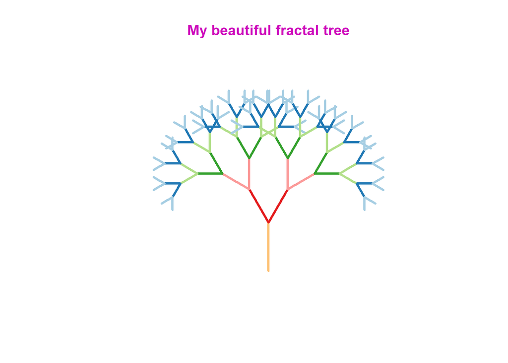

```r
initiate_tree()
tree_rec(rec_factor = 7)
```

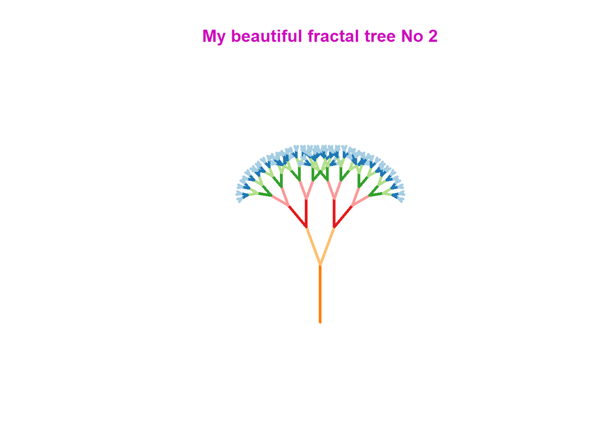

```r
initiate_tree(my_title = "My beautiful fractal tree No 2")
tree_rec(angle = pi/9, scale = 0.7, rec_factor = 8)
```

```r
forest_pos <- c(complex(real = -0.5, imaginary = 0.3), complex(real = -1, imaginary = 0), complex(real = 0.5, imaginary = 0.5),
                complex(real = 0.7, imaginary = 0.2), complex(real = 0, imaginary = 0))
forest_stem <- forest_pos + complex(real = 0, imaginary = 0.6)


initiate_tree(l_corner = c(-2.5,3), r_corner = c(0,3), my_title = "My beautiful fractal forest")

for (i in 1: length(forest_pos))
{
tree_rec(rec_factor = 12, scale = 0.8, origin = forest_pos[i], branch = forest_stem[i])
}
```

[figure not shown]

### The great power in recursive algorithms (functions) lie in the break down of a problem into smaller problems.

**Examples of use of recursive functions within the health sector** (these are only notes of topics to be developed; the work is still in preparation):  
Markow Chains (Discrete-Time Markov Models for Spread of an Infectious Disease)  
Queueing theory (hospital beds, appointments)  
Decision trees (e.g., in diagnositics)  
Time series (forecasting)

## 10. Anonymous (inline lambda) functions

```r
  x <- 3
  y <- 2

  assign(paste0("Number_", x, "_", y), (function(x,y) x*y + x/y)(x, y))

  paste0(paste0("Number_", x, "_", y, ": "), get(paste0("Number_", x, "_", y)))
```

```
## [1] "Number_3_2: 7.5"
```

```r
  assign(paste0("Test_", x, "_", y), (\(x,y) x^y )(x, y))

  paste0(paste0("Test_", x, "_", y, ": "), get(paste0("Test_", x, "_", y)))
```

```
## [1] "Test_3_2: 9"
```

```r
  (function(x,y){x*y + x/y})(2,5)
```

```
## [1] 10.4
```

```r
  `{` <- function(...)
  base::`{`(
    if (length(sys.calls()) >= 4 &&
        identical(as.character(sys.call()[[1]]), "{") &&
        identical(as.character(sys.call(-4)[[1]]), "{"))
      base::`{`(fn <- new('function'),
        formals(fn) <- alist(x=), body(fn) <- sys.call(), fn)
    else eval.parent(substitute(base::`{`(...)))
  )
```

## 11. Infix Functions (expressions)

```r
'%Greater%' <- function(a, b)
{
  if(a > b) print(a)
  else if(b > a) print(b)
  else print("equal")
}
5 %Greater% 7
```

```
## [1] 7
```

```r
2300 %Greater% 67
```

```
## [1] 2300
```

## 12. Miscellaneous

### 12.1. What happens if you use the name of a common R function?

```r
sum(3,2)
```

```
## [1] 5
```

Let’s write a user defined function which uses as function name **sum**

```r
sum <- function(p1,p2) {"rrr"}
```

What happens now when I call function **sum**?

```r
sum(3,2)
```

```
## [1] "rrr"
```

By simply removing my user defined function object, R reverts to the in-built version of the function **sum**

```r
rm(sum)

sum(3,2)
```

```
## [1] 5
```

### 12.2. A function as argument of a function

fun <- function(x, fun2){ return(fun2(x)) }

### 12.3. Input arguments as vectors

The argument input for **int1** can also be a vector, in which case the output will also be a vector.

```r
intvec <- c(1,1,3,2,1)


arg1_fun(intvec)
```

```
## [1] "tiger"    "tiger"    "dolphin"  "kangeroo" "tiger"
```

For the simple function **arg1_fun** the input values for argument **int1** can be given as a vector, because a vector input makes still sense within in the function body code.

For many functions that is possible. However, for more complex functions with **several argument inputs**, this is often no longer possible or sensible (it depends on what the function body code does in detail).

[figure not shown]

```r
spiral_fun(c(1,2,10), -0.5, TRUE, 0.1)
```

[figure not shown]

```r
spiral_fun(10, -0.5 , c(TRUE, FALSE), 0.1)
```

You might therefore want to ‘fool-prove’ the function inside the **function body code** against vector inputs.

## 13. Function outputs: change a **global object value**

Remember, **global arguments** are ‘sitting’ in the main (**“global”**) body of your code **outside** of functions or function inputs.

To change the **global value** of an R object from **inside** a function, you can use the “double assignment operator” (**<<–**) within your function.

As an example, let’s look at a global R object **number_legs_dog** of class integer, which holds a value for the number of legs of a dog.

```r
number_legs_dog <- 4

number_legs_dog
```

```
## [1] 4
```

The following function returns as the number of legs of a dog the integer **7**.

```r
dog_fun <- function(){
  number_legs_dog <- 7
  print(paste0("number_legs_dog = ", number_legs_dog))
}
```

Let’s run the function, and see what happens.

```r
dog_fun()
```

```
## [1] "number_legs_dog = 7"
```

Let’s also check the value of our **global value** of **number_legs_dog**

```r
number_legs_dog
```

```
## [1] 4
```

The **global value** of **number_legs_dog** has not changed from **4**.

Let’s now introduce the double assignment operator **<<–** into our function **dog_fun**.

```r
## Using the double assignment operator to change the variable globally
dog_fun <- function(){
  number_legs_dog <<- 7
  print(paste0("number_legs_dog = ", number_legs_dog))
}
```

Let’s check the **global value of number_legs_dog** again.

```r
number_legs_dog
```

```
## [1] 4
```

The **global value of number_legs_dog** has still not changed from **4**.

Now let’s run the new version of the **new** function **dog_fun**:

```r
dog_fun()
```

```
## [1] "number_legs_dog = 7"
```

And check the **global value** again of **number_legs_dog**:

```r
number_legs_dog
```

```
## [1] 7
```

After running the new function **dog_fun** that uses the “double assignment operator”, the **global value** of **number_legs_dog** has now changed from **4** to **7**.

**Danger!!!**